# Analysis of Prosper loan data from Q4 2005 to Q1 2014

Let’s load the data and get an idea about its variables.

```
## 'data.frame':    113937 obs. of  84 variables:
##  $ ListingKey                         : Factor w/ 113066 levels "00003546482094282EF90E5",..: 7180 7193 6647 6669 6686 6689 6699 6706 6687 6687 ...
##  $ ListingNumber                      : int  193129 1209647 81716 658116 909464 1074836 750899 768193 1023355 1023355 ...
##  $ ListingCreationDate                : Factor w/ 113064 levels "2005-11-09 20:44:28.847000000",..: 14184 111894 6429 64760 85967 100310 72556 74019 97834 97834 ...
##  $ CreditGrade                        : Factor w/ 9 levels "","A","AA","B",..: 5 1 8 1 1 1 1 1 1 1 ...
##  $ Term                               : int  36 36 36 36 36 60 36 36 36 36 ...
##  $ LoanStatus                         : Factor w/ 12 levels "Cancelled","Chargedoff",..: 3 4 3 4 4 4 4 4 4 4 ...
##  $ ClosedDate                         : Factor w/ 2803 levels "","2005-11-25 00:00:00",..: 1138 1 1263 1 1 1 1 1 1 1 ...
##  $ BorrowerAPR                        : num  0.165 0.12 0.283 0.125 0.246 ...
##  $ BorrowerRate                       : num  0.158 0.092 0.275 0.0974 0.2085 ...
##  $ LenderYield                        : num  0.138 0.082 0.24 0.0874 0.1985 ...
##  $ EstimatedEffectiveYield            : num  NA 0.0796 NA 0.0849 0.1832 ...
##  $ EstimatedLoss                      : num  NA 0.0249 NA 0.0249 0.0925 ...
##  $ EstimatedReturn                    : num  NA 0.0547 NA 0.06 0.0907 ...
##  $ ProsperRating..numeric.            : int  NA 6 NA 6 3 5 2 4 7 7 ...
```

[output cut: 70 more lines]

## Number loans originated over time

That’s a lot of variables! Even with the variable definitions it’s hard to keep track of everything that’s going on. Let’s plot some data to start getting a handle on this data.

### By quarter

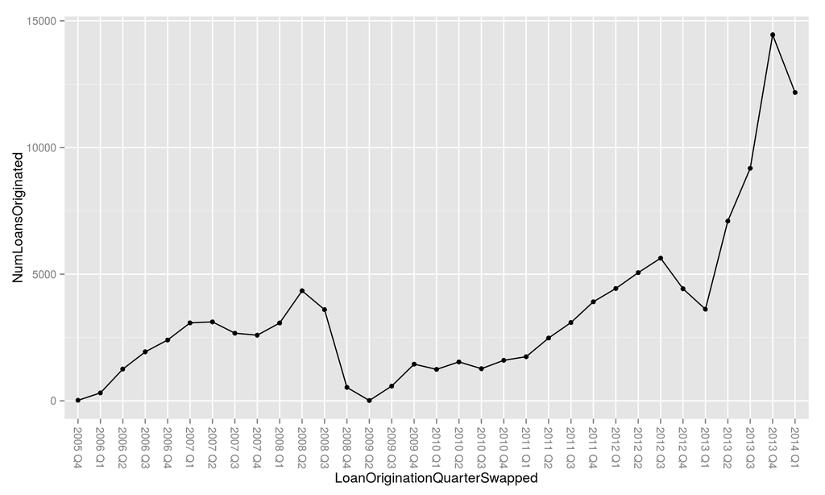

The earliest loans are from 2005-2006, when Prosper was founded and went public. There’s a drop after Q2 2008 (approaching nearly 0 in Q2 2009), likely because of the recession.

The loans started picking up again after that and gradually increased until the number of originated loans per quarter surpassed 5000, after which there was a drop in Q4 2012 and Q1 2013 after which loans started picking up again at an even greater rate.

It would be interesting to see if we could later try to understand the drop and the subsequent increased growth.

Grouping by month might reveal more details.

### By month

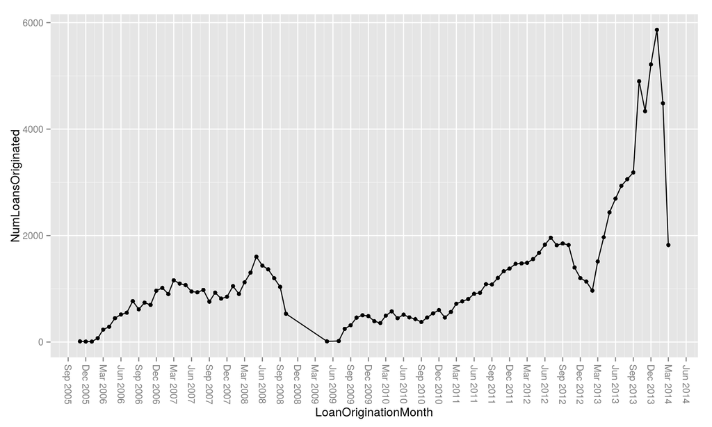

Grouped by months, the picture doesn’t look much different than before. We can tell that the trough in 2013 happed in February. We also see a steep drop off in March 2014 but it’s possible that this data set is not complete for March 2014 as it’s the last month in the data set.

What happens if we break down the loans by state?

### By month, broken down by state

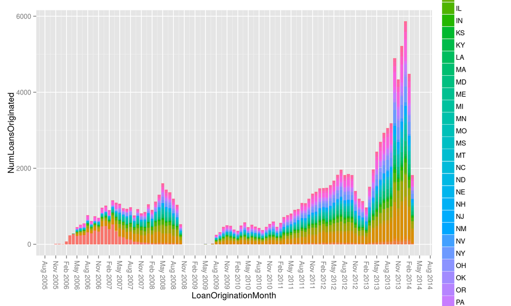

As expected, this graph is a bit hard to read due to the number of states, but it appears that most of the loans are concentrated in a small number of states so we can try looking at only some of the states. Before we do that, we can facet this data by state.

### By month, faceted by state

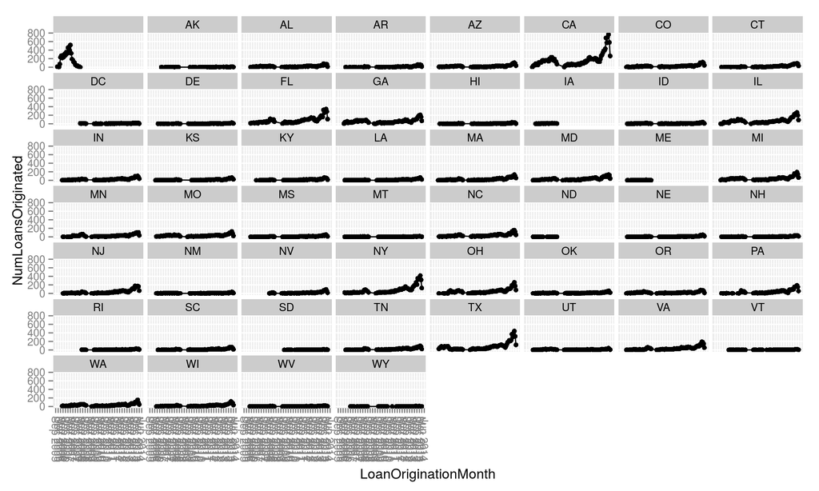

The trends in number of originated loans look similar, but we can see that in many states number of originated loans is pretty low. There’s also a number of loans with no state for earlier data.

## Amounts

How much money are people borrowing?

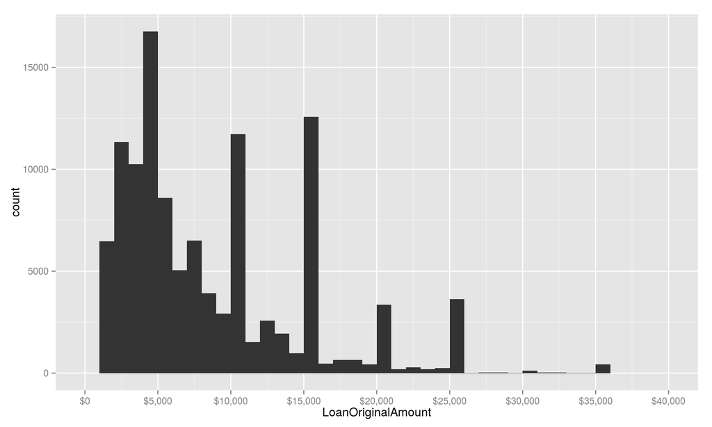

Loans amounts appear togo up to about $35,000. Most of the loans seem to be under $10,000. There are two peaks at around $10,000 and $15,000 and two smaller peaks around $20,000 and $25,000. Given that the peaks fall around very round numbers, I would speculate that people borrowing larger amounts would just pick a round number. Smaller differences would matter more when borrowing smaller amounts.

## Success rates

Let’s start looking at loan success rates. We first can break down the loans by status (grouped by origination date).

### Over time, by month

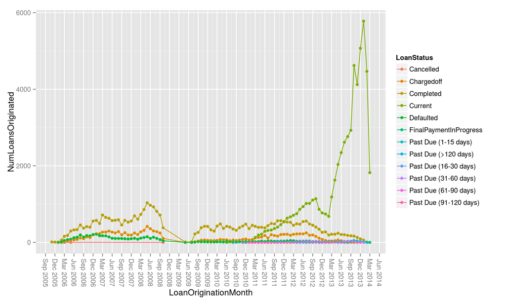

I’d like to explore the difference between succesful and unsuccesful loans, so I’m going to focus on comparing loans that were completed vs those that have been charged off.

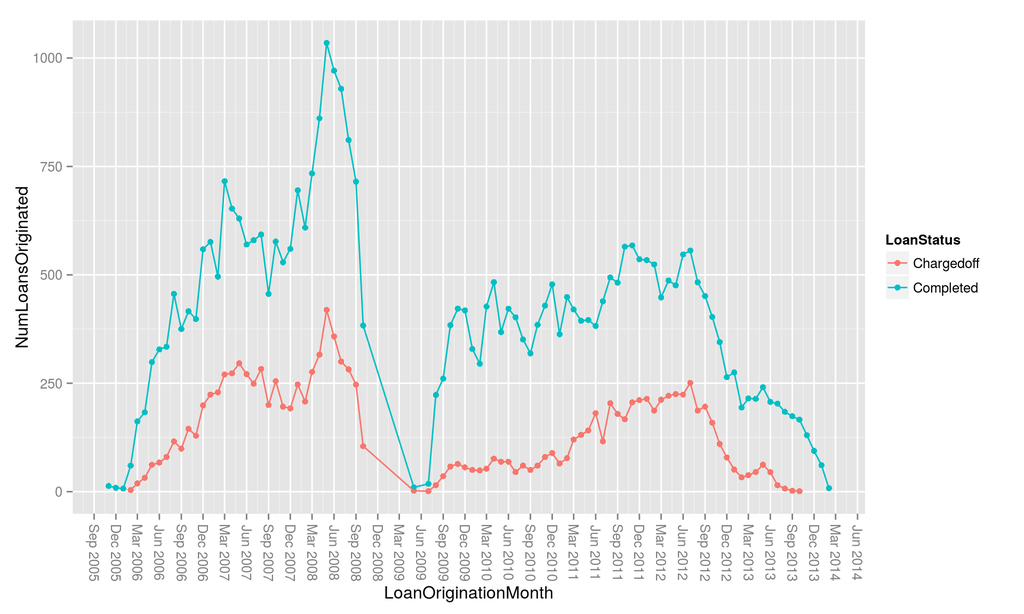

Loans starting from July 2009 have a Prosper “score” assigned to them which indicates a probability of a loan “going bad” on a scale from 1-11 with 11 being the best score. How do Prosper scores break down between completed and charged off loans?

### Over time, by month (only Chargedoff and Completed)

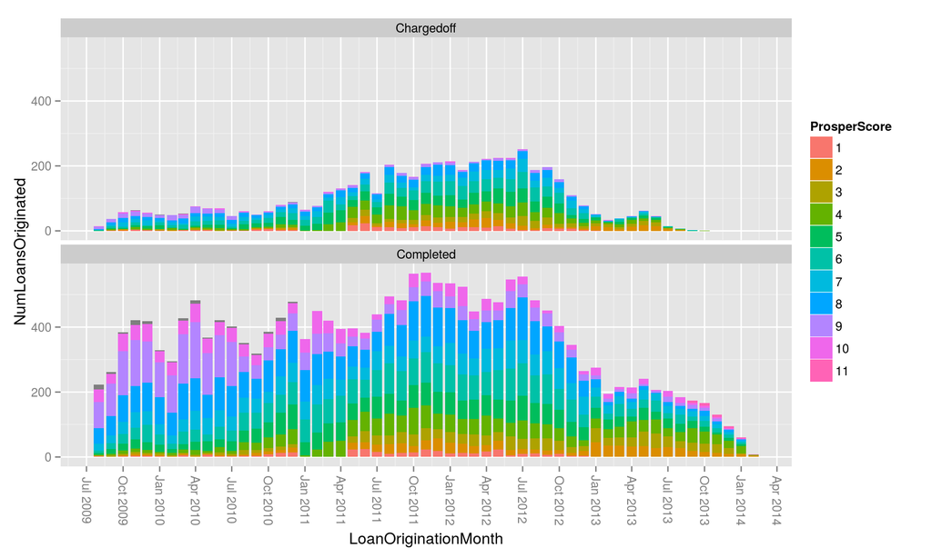

### Over time, by month (only Chargedoff and Completed, proportional)

Let’s normalize the counts to make the graph easier to interpret.

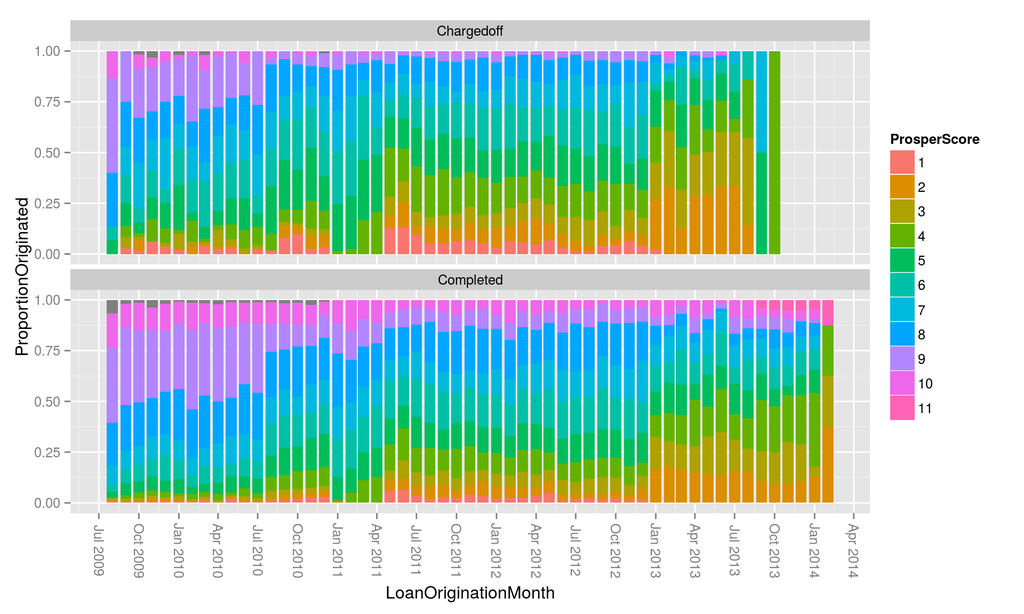

It’s a bit surprising that the proportion of scores are similar between the two sets. Initially the scores skew high, but become more distributed over time presumably as the platform opens up (both with more variety of people coming to the platform and as more sophisticated/return hungry lenders enter).

## Charge-off rates

Let’s look at some loan properties and see how they affect loan outcomes.

### By term

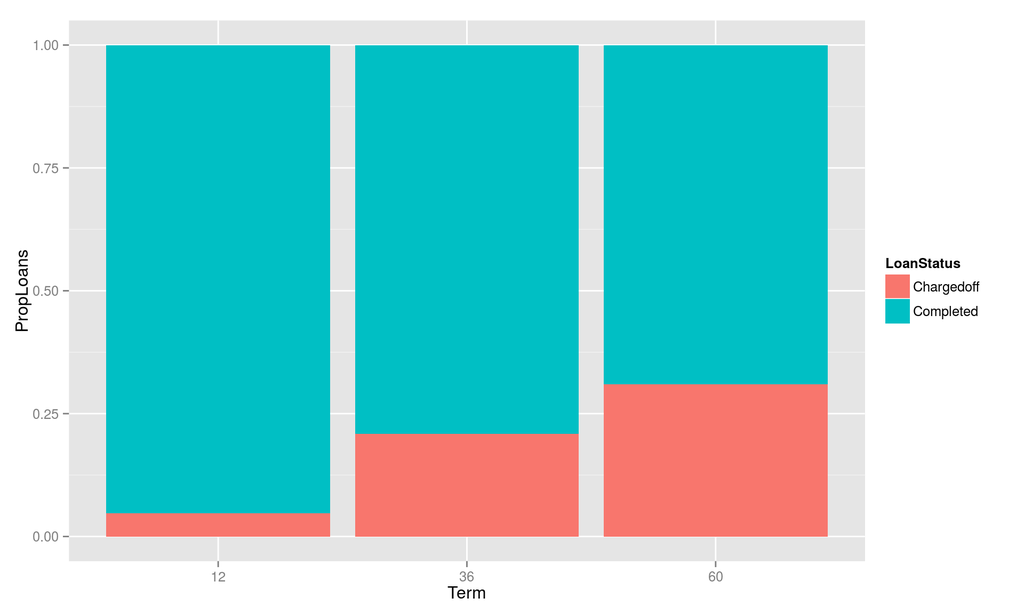

Here we see that loans with longer terms are charged off more often, but it’s difficult to draw any conclusions. Perhaps the nature of loans is different between shorter and longer term loans. It would be interesting to explore if there any other variables that correlate with loan term.

Let’s plot charged-off loans by various features vs loan term. For categorical variables, we’ll plot proportions attributed to different values of that feature and for continous variables we’ll show a scatter plot.

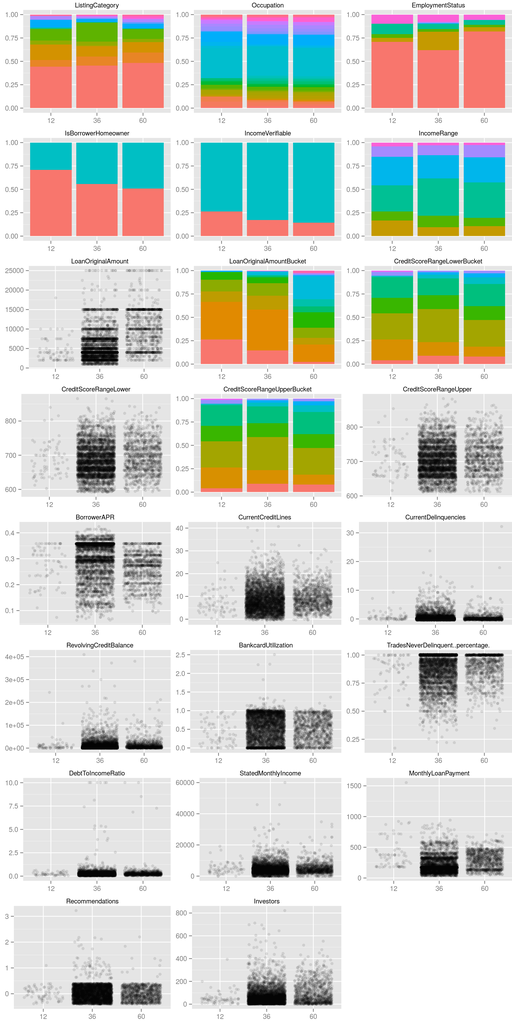

From the scatter plots, we notice that the number of 12-month loans is relatively low compared to 36 and 60 months loans. Given the low number of 12 month loans, focusing on the difference between 36 and 60 month loans is more meaningful.

The most interesting plot above, in my eyes, is the scatter plot of loan amounts. For the 36-month loans, there’s a heavy concentration of loans at $5000 and below. One potential explanation for the difference in charge-off rates is the difference in the distribution of loan amounts. Loans for higher amounts may be more likely to be charged off.

### By listing category

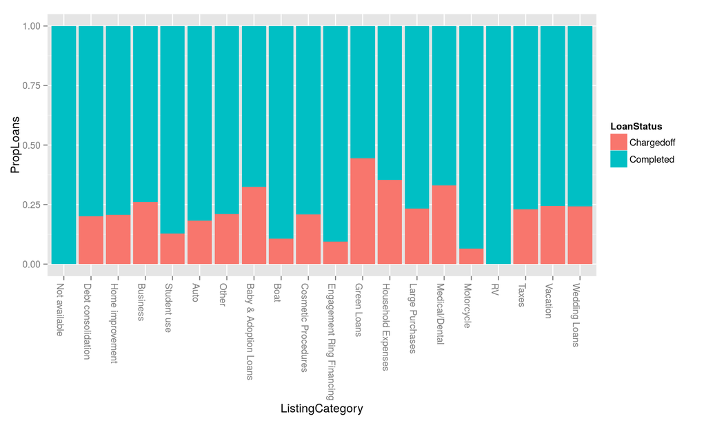

Charge-off rates vary quite a bit by category. Green loans appear to be the riskiest.

### By borrower state

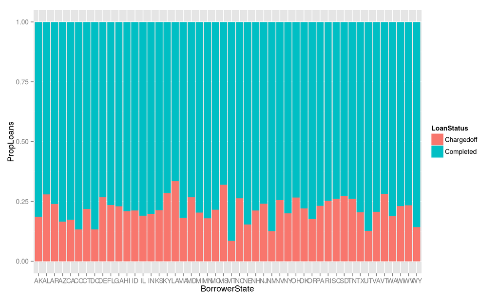

State does appear to affect charge-off reates, but me feeling is that it’s likely to be caused by different demographics and types of loans.

### By occupation

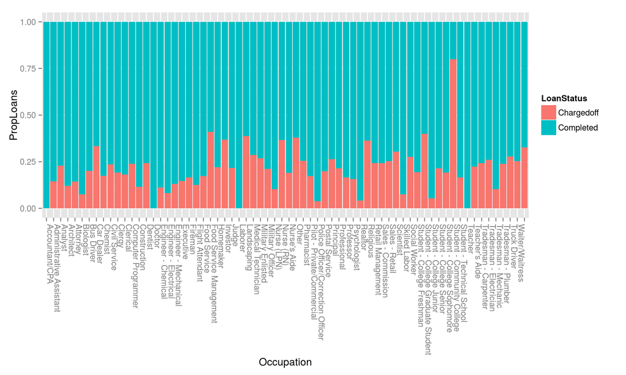

There’s great variety by occupation, but it’s not likely to be an effective indicator by itself. It would be worth looking at it in combination with other characteristics.

### By employment status, homeownership, verifiable income

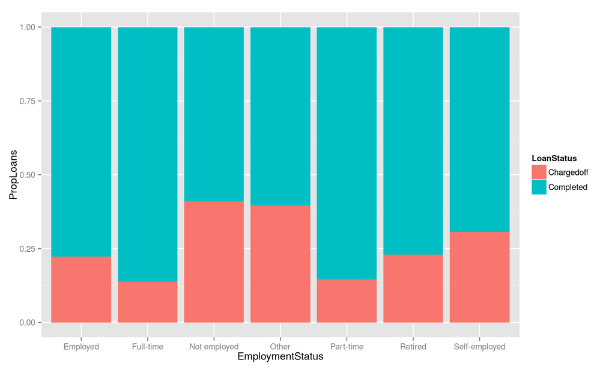

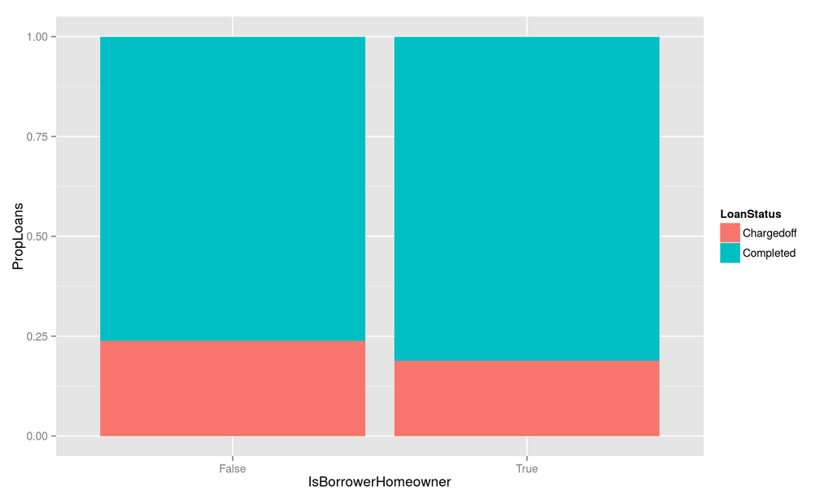

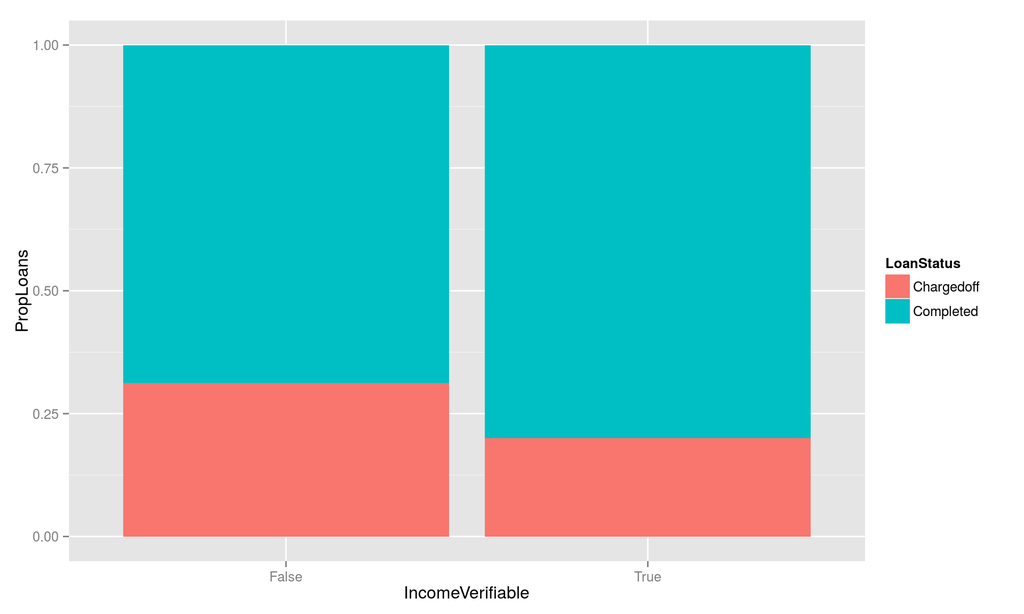

Same story for these characteristics. It’s hard to read into any of these individually.

### By borrower rate

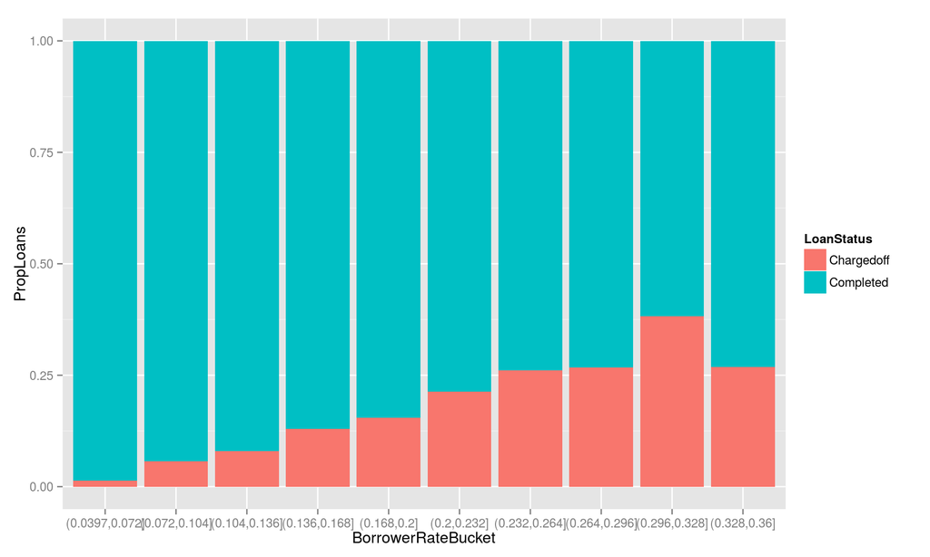

Here we see that loans with higher rates have a higher charge off rate, which is expected as riskier loans would have higher rates.

# Final Plots and Summary

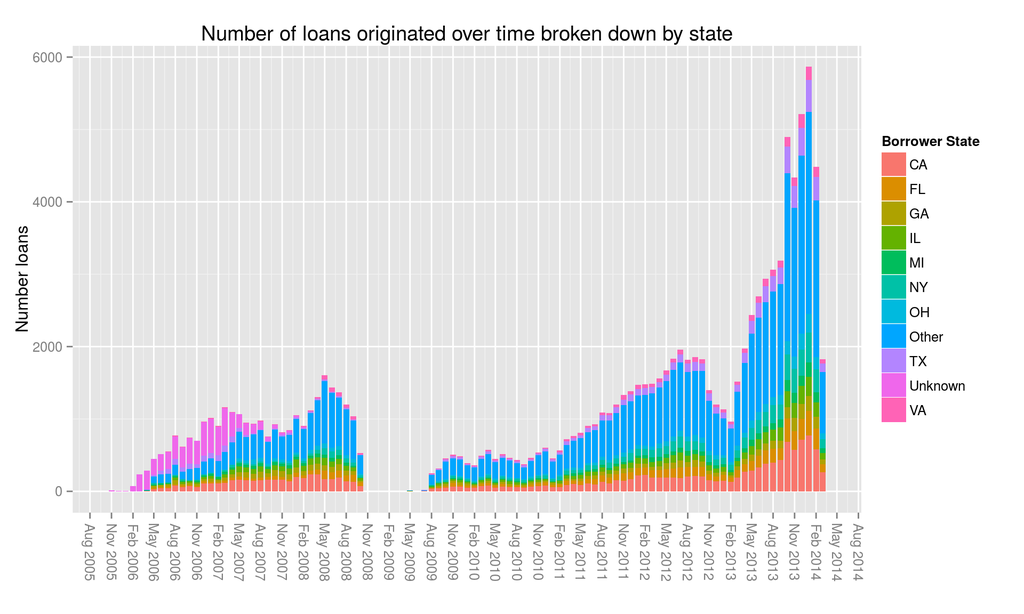

From this graph, we can see the trend in the number of loans originated on the Prosper platform. In the beginning the platform was growing steadily, but there was a sharp drop off in 2008, possibly related to the recession. There appears to be a gap in data until 2009 (according to TechCrunch, Prosper stopped originating new loans in September 2008 due to SEC scrutiny. Wikipedia indicates they re-launched in July, 2009).

Starting in 2009, the loans begun picking up again, only to see another decline starting end of 2012. I have not been able to identify the cause of this dropoff. After reaching a bottom in early 2013, the platform began growing again.

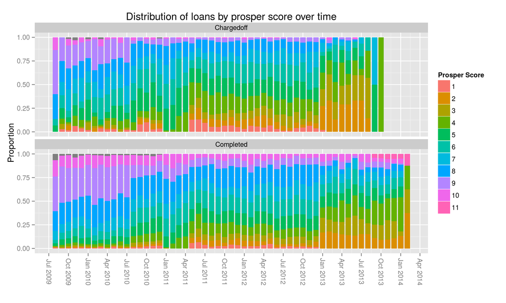

Here we see how the risk quality of loans has changed over time. Initially, the data is skewed towards higher quality loans but over time the quality of loans becomes more diversified. One possible explanation is that the investor pool grew larger as Prosper grew with more investors willing to take on riskier loans in exchange for higher rates.

Another possible contributing factor is changes to how the Prosper score is computed. Perhaps as Prosper matured, they were able to improve their models which might lead to changes in how loans are classified.

We also see that the distribution of charged-off loans trends to lower scores over time.

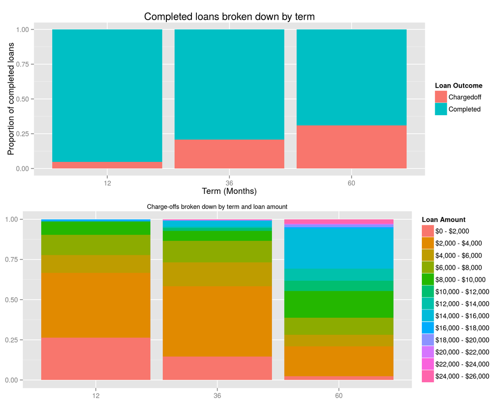

In the top panel, we see that the proportion of charged-off increases as the term of the loan increases.

In the bottom panel, we see a breakdown of the charged-off loans by loan amount. Longer term loans tend to be for higher amounts, which could explain the higher charge-off rates, but I’m cautious about drawing any conclusions as there are likely other factors that influence the loan amount that could explain away the higher charge-off rates.

# Reflection

This has been a challenging data set to work with due to the amount of variables. My analysis only scratched the surface of this data. Even looking at a small subset of the variables required quite a bit of effort. Someone more familiar with the subject might have known which variables were worth focusing on.

Another challenge is that many of the variables in this data set are not independent making it hard to make any inferences. One has to be very careful when trying to interpret this data as the relationships are tricky. If I were to do further analysis on this data set, I would focus on trying to understand the relationship between the various variables before trying to understand their relationship to loan success.